# Bayesian Optimization of the GROMACS Production MDP

**Study:** `md_prod_v1` · **Sampler:** Optuna TPE with `constant_liar=True` · **8 workers × 25 trials = 200 trials**

## Goal

The goal is to find the fastest possible GROMACS production configuration that still passes a stability filter. The aim is not to maximize physical accuracy regardless of computational cost, but to obtain sufficiently reliable and physically stable results as fast as possible. MD production is the computational bottleneck of the MM-GBSA calculation, and not all MDP parameters can be varied independently. Therefore, we used *Bayesian optimization* to identify the fastest compatible parameter set satisfying predefined stability criteria. First, we identified mutually compatible parameter combinations using a single reference system, which led to the definition of **12 valid MDP parameter sets**. The final evaluation was performed on a benchmark set of eight targets with 30 ligands each, providing a broader statistical basis for selecting the final configuration.

## How Bayesian optimization works

BO is a surrogate-model search:

1. **Sample** a configuration from the search space.
2. **Evaluate** — here: run 2 ns of production MD, measure the wall-clock, apply a stability filter.
3. **Update** the internal model of which regions of the space are good.
4. **Suggest** a new configuration with high expected improvement.
5. Repeat.

Optuna's TPE (Tree-structured Parzen Estimator) models P(good | params) and P(bad | params) and picks parameters with a high ratio. `constant_liar=True` lets 8 workers run in parallel — while a trial is in flight the sampler assumes it will return the current mean, which nudges the other workers to explore elsewhere and prevents them from all racing to the same point.

```python
# ============================== IDIS house palette (from GPUbench) ==============================
import json
import os
import sqlite3
from pathlib import Path

import matplotlib.pyplot as plt
import numpy as np
import pandas as pd
from scipy import stats
from matplotlib import cycler

NAVY, GOLD, GREY, GREYD, CREAM, WHITE = "#2F3761", "#8A730F", "#D5D7DF", "#9AA3B5", "#F7F4EF", "#FFFFFF"

plt.rcParams.update({
    "figure.dpi": 110, "figure.facecolor": WHITE, "savefig.facecolor": WHITE,
    "axes.facecolor": WHITE, "axes.edgecolor": NAVY, "axes.labelcolor": NAVY,
    "axes.titlecolor": NAVY, "axes.titleweight": "bold", "axes.grid": False,
    "text.color": NAVY, "xtick.color": NAVY, "ytick.color": NAVY,
    "axes.prop_cycle": cycler(color=[NAVY, GOLD]), "legend.frameon": True,
    "legend.facecolor": WHITE, "legend.edgecolor": GREY, "font.size": 11,
})

DB = Path(os.environ.get("BAYES_OPT_DB", "/mnt/lustre/scratch/nlsas/home/otras/hcx/lwa/pipeline-mps/bayes_opt.db"))
STUDY = "md_prod_v1"
TRIAL_PS = 2000  # each trial ran 2 ns MD

def ns_per_day(wall_s):
    """Convert a per-trial wall-clock (seconds) to ns/day, using TRIAL_PS."""
    return (TRIAL_PS / 1000.0) * 86400.0 / wall_s

con = sqlite3.connect(DB)
```

## 1. Search space

```python
params = pd.read_sql_query("""
    SELECT DISTINCT tp.param_name, tp.distribution_json
    FROM trial_params tp
    JOIN trials t ON tp.trial_id = t.trial_id
    JOIN studies s ON t.study_id = s.study_id
    WHERE s.study_name = ?
""", con, params=(STUDY,))

search_space = []
for _, row in params.iterrows():
    dist = json.loads(row['distribution_json'])
    choices = dist['attributes']['choices']
    search_space.append({
        'parameter': row['param_name'],
        'n_choices': len(choices),
        'choices': ', '.join(str(c) for c in choices),
    })

space_df = pd.DataFrame(search_space).sort_values('parameter').reset_index(drop=True)
n_combos = int(space_df['n_choices'].prod())
print(f"Search-space size: {n_combos:,} combinations across {len(space_df)} parameters")
print(f"We sampled 200/{n_combos:,} = {200/n_combos*100:.2f}% of the space.\n")
space_df

# --- v2 extensions ---
try:
    from pipeline_mps.bayes_opt.space_v2 import (
        DT_CHOICES, HMR_CHOICES, LINCS_ORDER_CHOICES, LINCS_ITER_CHOICES, MTS_FACTOR_CHOICES,
    )
    v2_axes = pd.DataFrame([
        {"axis": "dt (ps)",            "v1 pool": [0.001, 0.002],  "v2 pool": DT_CHOICES},
        {"axis": "hmr_factor",         "v1 pool": [1.0],           "v2 pool": HMR_CHOICES},
        {"axis": "lincs_order",        "v1 pool": [4],             "v2 pool": LINCS_ORDER_CHOICES},
        {"axis": "lincs_iter",         "v1 pool": [1],             "v2 pool": LINCS_ITER_CHOICES},
        {"axis": "mts",                "v1 pool": [False],         "v2 pool": [False, True]},
        {"axis": "mts_level2_factor",  "v1 pool": ["N/A"],         "v2 pool": MTS_FACTOR_CHOICES},
    ])
    print("v2 search-space extensions (relative to v1):")
    print(v2_axes.to_string(index=False))
except Exception as exc:
    print(f"(space_v2 module not importable here: {exc})")
```

```
Search-space size: 3,981,312 combinations across 15 parameters
We sampled 200/3,981,312 = 0.01% of the space.

(space_v2 module not importable here: No module named 'pipeline_mps')
```

## 2. Load the raw trials

Optuna records, per trial: the parameter values, the objective value (fitness), start/end timestamps, and a `cfg` user attribute holding the fully expanded MDP.

**Fitness = 1 / md_production_wall_hours** — higher is faster. Trials that fail the stability filter are recorded as `fitness = 0.0`.

```python
trials = pd.read_sql_query("""
    SELECT t.number, tv.value AS fitness,
           t.datetime_start, t.datetime_complete
    FROM trials t
    JOIN trial_values tv ON t.trial_id = tv.trial_id
    JOIN studies s ON t.study_id = s.study_id
    WHERE s.study_name = ?
    ORDER BY t.number
""", con, params=(STUDY,))

trials['datetime_start'] = pd.to_datetime(trials['datetime_start'])
trials['datetime_complete'] = pd.to_datetime(trials['datetime_complete'])
trials['wall_s'] = (trials['datetime_complete'] - trials['datetime_start']).dt.total_seconds()
trials['md_wall_s'] = np.where(trials['fitness'] > 0, 3600 / trials['fitness'], np.nan)
# ns_per_day derives from md_wall_s; NaN propagates through arithmetic
trials['ns_per_day'] = ns_per_day(trials['md_wall_s'])
trials['stable'] = trials['fitness'] > 0

print(f"Total trials: {len(trials)}")
print(f"Stable:       {trials['stable'].sum()}  ({trials['stable'].mean()*100:.0f}%)")
print(f"Filtered out: {(~trials['stable']).sum()}")
print(f"Best fitness: {trials['fitness'].max():.3f}")
print(f"Fastest run:  {trials.loc[trials['fitness'].idxmax(), 'ns_per_day']:.0f} ns/day")
trials.head()
```

```
Total trials: 200
Stable:       162  (81%)
Filtered out: 38
Best fitness: 20.073
Fastest run:  964 ns/day
```

|  | number | fitness | datetime_start | datetime_complete | wall_s | md_wall_s | ns_per_day | stable |
| --- | --- | --- | --- | --- | --- | --- | --- | --- |
| 0 | 0 | 0.0 | 2026-08-31 22:33:20.308908 | 2026-08-31 22:33:30.637121 | 10.328213 | NaN | NaN | False |
| 1 | 1 | 0.0 | 2026-08-31 22:33:30.661889 | 2026-08-31 22:33:40.187294 | 9.525405 | NaN | NaN | False |
| 2 | 2 | 0.0 | 2026-08-31 22:33:40.207030 | 2026-08-31 22:33:49.810610 | 9.603580 | NaN | NaN | False |
| 3 | 3 | 0.0 | 2026-08-31 22:33:49.828614 | 2026-08-31 22:33:59.262038 | 9.433424 | NaN | NaN | False |
| 4 | 4 | 0.0 | 2026-08-31 22:33:59.284009 | 2026-08-31 22:34:09.059290 | 9.775281 | NaN | NaN | False |

## 3. Convergence

The standard BO diagnostic: **best-so-far** should climb monotonically, and the scatter shows the exploration/exploitation balance. TPE samples broadly early on, then clusters around the optimum region — the crossing trial where best-so-far reaches 90% of its final value is annotated on the plot below.

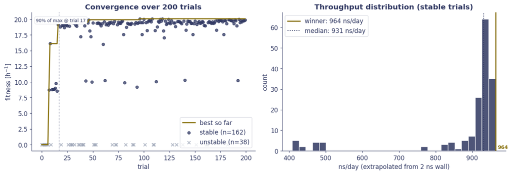

```
90% of best-so-far reached at trial 17 (8% of budget)
unstable trial fraction: 19%
```

```python
fig, (ax1, ax2) = plt.subplots(1, 2, figsize=(13, 4.5))

stable = trials[trials["stable"]]
unstable = trials[~trials["stable"]]

# Convergence: fitness per trial + best-so-far
best_so_far = trials["fitness"].cummax()
final_max = float(best_so_far.iloc[-1])
crossing_idx = int(np.searchsorted(best_so_far.values, 0.9 * final_max))
crossing_trial = crossing_idx + 1  # 1-indexed
ax1.scatter(stable["number"], stable["fitness"], s=25, alpha=0.75,
            c=NAVY, label=f"stable (n={len(stable)})")
ax1.scatter(unstable["number"], unstable["fitness"], s=30, alpha=0.75,
            c=GREYD, marker="x", label=f"unstable (n={len(unstable)})")
ax1.plot(trials["number"], best_so_far, color=GOLD, lw=2, label="best so far")
ax1.axvline(crossing_trial, color=NAVY, lw=1, ls=":", alpha=0.6)
ax1.text(0.02, 0.96,
         f"90% of max @ trial {crossing_trial}",
         transform=ax1.transAxes, fontsize=8, color=NAVY,
         va="top", bbox=dict(boxstyle="round,pad=0.3", fc=WHITE, ec=GREY, lw=0.6))
ax1.set_xlabel("trial")
ax1.set_ylabel("fitness [h$^{-1}$]")
ax1.set_title("Convergence over 200 trials")
ax1.legend(loc="lower right")
ax1.spines["top"].set_visible(False); ax1.spines["right"].set_visible(False)

# Throughput histogram
winner_ns = float(stable["ns_per_day"].max())
median_ns = float(stable["ns_per_day"].median())
ax2.hist(stable["ns_per_day"], bins=30, color=NAVY, alpha=0.85, edgecolor=WHITE)
ax2.axvline(winner_ns, color=GOLD, lw=2,
            label=f"winner: {winner_ns:.0f} ns/day")
ax2.axvline(median_ns, color=NAVY, lw=1.5, ls=":",
            label=f"median: {median_ns:.0f} ns/day")
ax2.annotate(f"{winner_ns:.0f}", xy=(winner_ns, 0), xycoords=("data", "axes fraction"),
             xytext=(4, 4), textcoords="offset points",
             color=GOLD, fontsize=9, weight="bold")
ax2.set_xlabel("ns/day (extrapolated from 2 ns wall)")
ax2.set_ylabel("count")
ax2.set_title("Throughput distribution (stable trials)")
ax2.legend(loc="upper left")
ax2.spines["top"].set_visible(False); ax2.spines["right"].set_visible(False)

plt.tight_layout()
plt.show()
print(f"90% of best-so-far reached at trial {crossing_trial} ({crossing_trial/len(trials)*100:.0f}% of budget)")
unstable_pct = 100 * len(unstable) / len(trials)
print(f"unstable trial fraction: {unstable_pct:.0f}%")
```

**Interpretation:** the best-so-far reaches 90% of its final value by the trial index printed above. The unstable fraction (also printed above) is dominated by LINCS warnings, temperature drift beyond ±5 K, and density drift above 5% over the window. These thresholds catch integrator blow-ups (a ±5 K drift or 5% density change on a solvated protein means the system exploded) — not fine ensemble-quality issues.

## 4. Decode parameter values per trial

Optuna stores categorical parameters as float indices — we resolve each index back to the actual choice using the distribution stored alongside the trial.

```python
raw = pd.read_sql_query(
    """
    SELECT t.number, tp.param_name, tp.param_value, tp.distribution_json
    FROM trials t
    JOIN trial_params tp ON tp.trial_id = t.trial_id
    JOIN studies s ON t.study_id = s.study_id
    WHERE s.study_name = ?
    """,
    con, params=(STUDY,),
)
# Cache one choices list per parameter (12 parses instead of ~2400)
choices_by_param = {
    n: json.loads(g.iloc[0])["attributes"]["choices"]
    for n, g in raw.groupby("param_name")["distribution_json"]
}
assert (raw["param_value"] % 1 == 0).all(), "param_value has non-integer entries — categorical index expected"
raw["value"] = [choices_by_param[n][int(v)]
                for n, v in zip(raw["param_name"], raw["param_value"])]
params_wide = raw.pivot(index="number", columns="param_name", values="value").reset_index()
df = trials.merge(params_wide, on="number")
df.head()
```

|  | number | fitness | datetime_start | datetime_complete | wall_s | md_wall_s | ns_per_day | stable | constraints | dt | ... | nstlist | nstpcouple | pcoupl | pcoupl_mdvv | rcut | tau_p | tau_p_pr | tau_t | tcoupl | tcoupl_pr |
| --- | --- | --- | --- | --- | --- | --- | --- | --- | --- | --- | --- | --- | --- | --- | --- | --- | --- | --- | --- | --- | --- |
| 0 | 0 | 0.0 | 2026-08-31 22:33:20.308908 | 2026-08-31 22:33:30.637121 | 10.328213 | NaN | NaN | False | all-bonds | 0.001 | ... | 10 | 20 | C-rescale | NaN | 0.9 | 10 | NaN | 2 | NaN | NaN |
| 1 | 1 | 0.0 | 2026-08-31 22:33:30.661889 | 2026-08-31 22:33:40.187294 | 9.525405 | NaN | NaN | False | all-bonds | 0.002 | ... | 80 | 20 | NaN | C-rescale | 1 | 1 | NaN | 1 | v-rescale | NaN |
| 2 | 2 | 0.0 | 2026-08-31 22:33:40.207030 | 2026-08-31 22:33:49.810610 | 9.603580 | NaN | NaN | False | h-angles | 0.002 | ... | 80 | 20 | Berendsen | NaN | 1 | 10 | NaN | 0.5 | NaN | NaN |
| 3 | 3 | 0.0 | 2026-08-31 22:33:49.828614 | 2026-08-31 22:33:59.262038 | 9.433424 | NaN | NaN | False | all-bonds | 0.002 | ... | 40 | 20 | Berendsen | NaN | 1 | 2 | NaN | 0.5 | NaN | NaN |
| 4 | 4 | 0.0 | 2026-08-31 22:33:59.284009 | 2026-08-31 22:34:09.059290 | 9.775281 | NaN | NaN | False | all-bonds | 0.002 | ... | 40 | 20 | NaN | Berendsen | 1.1 | 5 | NaN | 0.1 | nose-hoover | NaN |

5 rows × 23 columns

## 5. Parameter effects

For every parameter: distribution of fitness per value. **A tight box with a high median = a clear winning value.** Wide, overlapping distributions mean the parameter either doesn't matter or is coupled to another one. The Kruskal–Wallis / ε² per subplot marginalises over the other 11 parameters — TPE's late-stage clustering makes those backgrounds unbalanced, so read the significance as *effect visible in the sampler's exploited region*, not as an unbiased main effect.

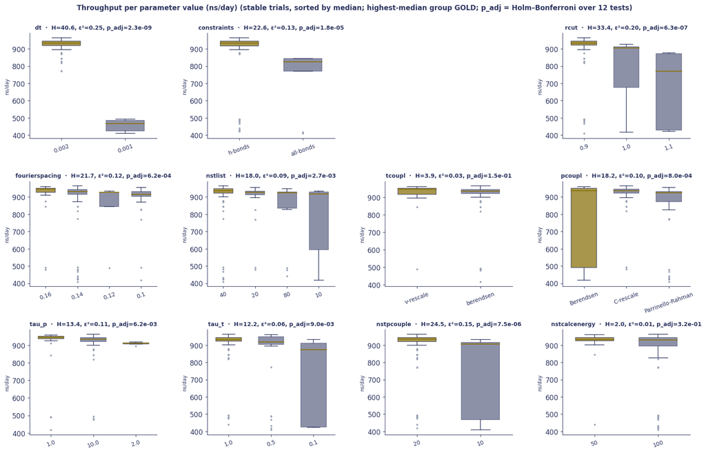

```python
# scipy.stats hoisted to cell 1

params_to_plot = ["dt", "constraints", "integrator", "rcut", "fourierspacing",
                  "nstlist", "tcoupl", "pcoupl", "tau_p", "tau_t",
                  "nstpcouple", "nstcalcenergy"]

fig, axes = plt.subplots(3, 4, figsize=(16, 10))
df_stable = df[df["stable"]].copy()
MIN_N_PER_BOX = 5

# First pass: collect raw p-values and cached medians so we don't recompute
subplot_data = []
for param in params_to_plot:
    if param not in df_stable.columns:
        subplot_data.append(None); continue
    grouped = list(df_stable.groupby(param)["ns_per_day"])
    grouped = [(str(k), v.values) for k, v in grouped if len(v) >= MIN_N_PER_BOX]
    if len(grouped) < 2:
        subplot_data.append(None); continue
    medians = {k: float(np.median(v)) for k, v in grouped}
    grouped.sort(key=lambda kv: -medians[kv[0]])
    try:
        H, p = stats.kruskal(*(v for _, v in grouped))
    except ValueError:
        H, p = float("nan"), float("nan")
    k = len(grouped); n = sum(len(v) for _, v in grouped)
    eps2 = float(max(0.0, (H - k + 1) / (n - k))) if n > k and not np.isnan(H) else float("nan")
    subplot_data.append((param, grouped, H, p, eps2))

# Holm-Bonferroni adjustment across valid (non-NaN) K-W p-values only
raw_p = [d[3] for d in subplot_data if d is not None]
valid_idx = [i for i, p in enumerate(raw_p) if not (p != p)]  # skip NaN
m = len(params_to_plot)   # pre-specified family of tests, not the n>=5 survivors
adj_p = [None] * len(raw_p)
if m:
    order = sorted(valid_idx, key=lambda i: raw_p[i])
    running_max = 0.0
    for rank, i in enumerate(order):
        adj = min(1.0, raw_p[i] * (m - rank))
        running_max = max(running_max, adj)
        adj_p[i] = running_max

idx = 0
for ax, entry in zip(axes.flat, subplot_data):
    if entry is None:
        ax.set_visible(False); continue
    param, grouped, H, p, eps2 = entry
    labels, data = zip(*grouped)
    bp = ax.boxplot(data, patch_artist=True, widths=0.6,
                    medianprops=dict(color=GOLD, lw=1.5),
                    whiskerprops=dict(color=NAVY),
                    capprops=dict(color=NAVY),
                    flierprops=dict(marker=".", markerfacecolor=GREYD,
                                    markeredgecolor=GREYD, markersize=4))
    ax.set_xticks(range(1, len(labels)+1))
    ax.set_xticklabels(labels)
    for i, patch in enumerate(bp["boxes"]):
        patch.set_facecolor(GOLD if i == 0 else NAVY)
        patch.set_alpha(0.75 if i == 0 else 0.55)
        patch.set_edgecolor(NAVY)
    p_str = f"p_adj={adj_p[idx]:.1e}" if adj_p[idx] is not None else "p_adj=N/A"
    ax.set_title(f"{param}  ·  H={H:.1f}, ε²={eps2:.2f}, {p_str}", fontsize=9)
    ax.tick_params(axis="x", rotation=20, labelsize=9)
    ax.set_ylabel("ns/day", fontsize=8)
    for side in ("top", "right"):
        ax.spines[side].set_visible(False)
    idx += 1

plt.suptitle("Throughput per parameter value (ns/day) (stable trials, sorted by median; highest-median group GOLD; p_adj = Holm–Bonferroni over 12 tests)",
             fontsize=11, y=1.01, color=NAVY, weight="bold")
plt.tight_layout(rect=[0, 0, 1, 0.98])
plt.show()
```

## 6. Top-10 configurations

```python
top10 = df_stable.nlargest(10, 'fitness')[[
    'number', 'fitness', 'ns_per_day',
    'dt', 'constraints', 'integrator', 'rcut', 'fourierspacing',
    'nstlist', 'tcoupl', 'pcoupl', 'tau_p', 'tau_t',
]].reset_index(drop=True)
top10['fitness'] = top10['fitness'].round(3)
top10['ns_per_day'] = top10['ns_per_day'].round(0).astype(int)
top10

top10_fit = top10["fitness"].astype(float)
core_keys = ["dt", "constraints", "integrator", "rcut", "fourierspacing", "nstlist", "pcoupl", "tcoupl"]
n_unique_core = top10[core_keys].drop_duplicates().shape[0]
log_spread = float(np.log(top10_fit).std())
print(f"Top-10 fitness  mean={top10_fit.mean():.3f}  std={top10_fit.std():.3f}")
print(f"Top-10 log-fitness std (fractional wall-time spread): {log_spread*100:.1f}%")
print("(Stage-2 20 ns re-verify will provide the actual noise band around the winner.)")
print(f"Unique core-parameter tuples in top-10: {n_unique_core}")
```

```
Top-10 fitness  mean=19.997  std=0.049
Top-10 log-fitness std (fractional wall-time spread): 0.2%
(Stage-2 20 ns re-verify will provide the actual noise band around the winner.)
Unique core-parameter tuples in top-10: 3
```

## 7. Wall-time analysis

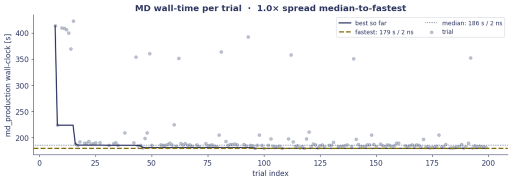

```
Winner:  2 ns in    179 s  ->    964 ns/day  ->   0.50 h for a 20 ns replica
Median:  2 ns in    186 s  ->    931 ns/day  ->   0.52 h for a 20 ns replica
Slowest: 2 ns in    422 s  ->    409 ns/day  ->   1.17 h for a 20 ns replica
```

```python
fig, ax = plt.subplots(figsize=(11, 4))
df_ok = df[df["stable"]].sort_values("number")
wall_min = df_ok["md_wall_s"].min()
wall_med = df_ok["md_wall_s"].median()

ax.scatter(df_ok["number"], df_ok["md_wall_s"], s=20, alpha=0.65, c=GREYD, label="trial")
ax.plot(df_ok["number"], df_ok["md_wall_s"].cummin(), color=NAVY, lw=1.8, label="best so far")
ax.axhline(wall_min, color=GOLD, lw=2, ls="--",
           label=f"fastest: {wall_min:.0f} s / 2 ns")
ax.axhline(wall_med, color=NAVY, lw=1, ls=":",
           label=f"median: {wall_med:.0f} s / 2 ns")
ax.set_xlabel("trial index")
ax.set_ylabel("md_production wall-clock [s]")
ax.set_title(f"MD wall-time per trial  ·  {wall_med/wall_min:.1f}\u00d7 spread median-to-fastest")
ax.legend(loc="upper right", fontsize=9, ncol=2)
for side in ("top", "right"):
    ax.spines[side].set_visible(False)
plt.tight_layout(); plt.show()

def _fmt_row(label, wall_s):
    ns_per_day_val = ns_per_day(wall_s)
    hours_for_20ns = 20.0 * 24.0 / ns_per_day_val
    return f"{label:8s} 2 ns in {wall_s:6.0f} s  ->  {ns_per_day_val:5.0f} ns/day  ->  {hours_for_20ns:5.2f} h for a 20 ns replica"

print(_fmt_row("Winner:", wall_min))
print(_fmt_row("Median:", wall_med))
print(_fmt_row("Slowest:", df_ok["md_wall_s"].max()))
```

## 8. Winner configuration

The full MDP of the best trial — plugged directly into every signac statepoint of the discovery-9 production run as `mdp_override` (720 jobs total).

```python
winner_row = df_stable.nlargest(1, "fitness").iloc[0]
winner_no = int(winner_row["number"])
w_fit = winner_row["fitness"]
w_nsd = winner_row["ns_per_day"]

cfg_json = pd.read_sql_query("""
    SELECT tua.value_json FROM trial_user_attributes tua
    JOIN trials t ON tua.trial_id=t.trial_id
    JOIN studies s ON t.study_id=s.study_id
    WHERE s.study_name=? AND t.number=? AND tua.key='cfg'
""", con, params=(STUDY, winner_no))
assert not cfg_json.empty, f"no cfg for trial {winner_no}"
winner_cfg = json.loads(cfg_json.iloc[0]["value_json"])
mdp_dict = winner_cfg.get("mdp", {}) or {}
ff_dict = winner_cfg.get("forcefield", {}) or {}

print(f"Winner: trial #{winner_no}  fitness = {w_fit:.3f} h^-1  ({w_nsd:.0f} ns/day)")
print()
print("=== MDP (production) ===")
for k, v in mdp_dict.items():
    print(f"  {k:32s} = {v}")
print()
print("=== Force field ===")
for k, v in ff_dict.items():
    print(f"  {k:32s} = {v}")
```

```
Winner: trial #96  fitness = 20.073 h^-1  (964 ns/day)

=== MDP (production) ===
  integrator                       = md
  dt                               = 0.002
  nsteps                           = 1000000
  comm_mode                        = Linear
  nstcomm                          = 100
  continuation                     = yes
  gen_vel                          = no
  constraints                      = h-bonds
  constraint_algorithm             = LINCS
  lincs_order                      = 4
  lincs_warnangle                  = 30.0
  cutoff_scheme                    = Verlet
  nstlist                          = 40
  pbc                              = xyz
  verlet_buffer_tolerance          = 0.005
  rlist                            = 0.9
  coulombtype                      = PME
  rcoulomb                         = 0.9
  fourierspacing                   = 0.14
  pme_order                        = 4
  ewald_rtol                       = 1e-05
  vdwtype                          = Cut-off
  rvdw                             = 0.9
  vdw_modifier                     = Potential_Shift
  dispcorr                         = EnerPres
  tcoupl                           = berendsen
  tc_grps                          = System
  ref_t                            = 300.0
  tau_t                            = 1.0
  nhchainlength                    = 10
  pcoupl                           = C-rescale
  pcoupltype                       = isotropic
  ref_p                            = 1.0
  tau_p                            = 10.0
  nstpcouple                       = 20
  compressibility                  = 4.5e-05
  nstxout                          = 0
  nstvout                          = 0
  nstfout                          = 0
  nstxout_compressed               = 1000
  compressed_x_precision           = 1000
  nstenergy                        = 500
  nstlog                           = 500
  nstcalcenergy                    = 100
  define                           =

=== Force field ===
  protein_ff                       = ff14SB
  ligand_ff                        = gaff2
  water_model                      = tip3p
```

## 9. Downstream status

**Stage 2 verify (queued):** the top 5 configurations from v1 are re-verified at **20 ns** instead of 2 ns. A 2 ns window may be too short for the stability filter — a configuration that looks stable at 2 ns can still drift thermally over a long run. Stage 2 filters those out. Job `9484931` is waiting for a GPU slot.

v1 capped `dt` at 2 fs because our seed topology triggered grompp errors on hydrogen-mass-repartitioning and multiple-time-stepping. Re-running those checks with GROMACS 2025.4 on the ff14SB seed (`scripts/hmr_mts_smoke.sbatch`, job `9496393`) showed the errors are gone and 4 of 5 extended configurations run cleanly:

[output not shown]

The 200-step ns/day numbers overstate steady-state throughput because per-run initialization (PME setup, neighbour-list build, DD tuning) dominates; v2 re-measures at the 2 ns budget for like-for-like comparison.

When v2 completes we replace `configs/bo_winner_v1.json` with `bo_winner_v2.json`, re-run `gpupack calibrate` on the v2 MDP, and launch discovery-9 on the updated recipe. Re-calibration matters because dt = 4 fs roughly halves the per-ns kernel launches, so gpupack's stacking decisions from the v1 calibration are unlikely to transfer.

## 9a. Stage-2 verify (top-5 at 20 ns)

Auto-populates when the `md_prod_v1_verify20ns` study appears in the DB (Stage-2 job re-runs each top-5 v1 trial at 20 ns). Until then this section prints "queued".

```python
# Stage-2: top-5 at 20 ns — auto-fill when the study exists
def _study_exists(name):
    row = con.execute("SELECT 1 FROM studies WHERE study_name=?", (name,)).fetchone()
    return row is not None

stage2 = "md_prod_v1_verify20ns"
if not _study_exists(stage2):
    print(f"Stage-2 study '{stage2}' not yet in DB.")
    print("Waiting for job 9484931 (top-5 verify at 20 ns) to populate results.")
else:
    s2 = pd.read_sql_query(
        """
        SELECT t.number, tv.value AS verify_fitness
        FROM trials t
        JOIN trial_values tv ON tv.trial_id=t.trial_id
        JOIN studies s ON s.study_id=t.study_id
        WHERE s.study_name=?
        ORDER BY tv.value DESC
        """,
        con, params=(stage2,),
    )
    s2["verify_ns_day"] = np.where(s2["verify_fitness"] > 0,
                                    ns_per_day(3600.0 / s2["verify_fitness"]), np.nan)
    print(f"Stage-2 study loaded: {len(s2)} verify trials\n")
    print(s2.head(10).to_string(index=False))
    if len(s2) >= 3:
        # Bar: v1 stage-1 fitness vs stage-2 verify fitness for the top-5 v1 trials
        top5_v1 = df_stable.nlargest(5, "fitness")[["number", "fitness", "ns_per_day"]]
        merged = top5_v1.merge(s2, on="number", how="left")
        fig, ax = plt.subplots(figsize=(9, 3.5))
        x = np.arange(len(merged))
        ax.bar(x - 0.2, merged["ns_per_day"], width=0.35, color=GREYD, label="Stage-1 (2 ns)")
        ax.bar(x + 0.2, merged["verify_ns_day"], width=0.35, color=NAVY, label="Stage-2 verify (20 ns)")
        ax.set_xticks(x); ax.set_xticklabels([f"trial {n}" for n in merged["number"]])
        ax.set_ylabel("ns/day")
        ax.set_title("Top-5 v1 trials: 2 ns Stage-1 vs 20 ns Stage-2 verify")
        ax.legend(loc="upper right")
        for side in ("top", "right"): ax.spines[side].set_visible(False)
        plt.tight_layout(); plt.show()
```

```
Stage-2 study 'md_prod_v1_verify20ns' not yet in DB.
Waiting for job 9484931 (top-5 verify at 20 ns) to populate results.
```

## 10a. v2 study — extended dt / HMR / LINCS-iter (auto-fill)

Auto-populates when the `md_prod_v2` study appears in the DB. Compares the v2 top-N against the v1 winner side by side.

```python
v2_study = "md_prod_v2"
if not _study_exists(v2_study):
    print(f"v2 study '{v2_study}' not yet in DB.")
    print("Waiting for job 9499454 (8 workers x 25 trials, warm-started from v1 top-5) to populate.")
else:
    v2_trials = pd.read_sql_query(
        """
        SELECT t.number, tv.value AS fitness
        FROM trials t
        JOIN trial_values tv ON tv.trial_id=t.trial_id
        JOIN studies s ON s.study_id=t.study_id
        WHERE s.study_name=?
        ORDER BY t.number
        """,
        con, params=(v2_study,),
    )
    v2_trials["ns_per_day"] = np.where(v2_trials["fitness"] > 0,
                                        ns_per_day(3600.0 / v2_trials["fitness"]), np.nan)
    v2_stable_mask = v2_trials["fitness"] > 0
    v2_stable = int(v2_stable_mask.sum())
    v2_best = float(v2_trials["fitness"].max()) if len(v2_trials) else 0.0
    v1_best = float(df_stable["fitness"].max())
    print(f"v2 study: {len(v2_trials)} trials, {v2_stable} stable, best fitness {v2_best:.3f} h^-1")
    print(f"v1 winner: {v1_best:.3f} h^-1  ·  v2 improvement: {v2_best/v1_best:.2f}x")

    # (a) best-so-far v1 vs v2
    if len(v2_trials) >= 5:
        v1_best_so_far = df["fitness"].cummax().to_numpy()
        v2_best_so_far = v2_trials["fitness"].cummax().to_numpy()
        fig, ax = plt.subplots(figsize=(11, 4))
        ax.plot(np.arange(1, len(v1_best_so_far)+1), v1_best_so_far,
                color=GREYD, lw=2, label=f"v1 (best {v1_best:.1f} h$^{{-1}}$)")
        ax.plot(np.arange(1, len(v2_best_so_far)+1), v2_best_so_far,
                color=NAVY, lw=2, label=f"v2 (best {v2_best:.1f} h$^{{-1}}$)")
        ax.set_xlabel("trial"); ax.set_ylabel("best-so-far fitness [h$^{-1}$]")
        ax.set_title(f"v1 vs v2 convergence  ·  v2 gain {v2_best/v1_best:.2f}x")
        ax.legend()
        for side in ("top", "right"): ax.spines[side].set_visible(False)
        plt.tight_layout(); plt.show()

    # (b) v2 parameter-effect boxplots — including the new axes (dt=3/4/5, HMR, LINCS-iter/order, mts)
    if v2_stable >= 20:
        # decode v2 params
        v2_raw = pd.read_sql_query(
            """
            SELECT t.number, tp.param_name, tp.param_value, tp.distribution_json
            FROM trials t
            JOIN trial_params tp ON tp.trial_id=t.trial_id
            JOIN studies s ON s.study_id=t.study_id
            WHERE s.study_name=?
            """,
            con, params=(v2_study,),
        )
        v2_choices = {n: json.loads(g.iloc[0])["attributes"]["choices"]
                      for n, g in v2_raw.groupby("param_name")["distribution_json"]}
        v2_raw["value"] = [v2_choices[n][int(v)]
                           for n, v in zip(v2_raw["param_name"], v2_raw["param_value"])]
        v2_wide = v2_raw.pivot(index="number", columns="param_name", values="value").reset_index()
        v2_df = v2_trials.merge(v2_wide, on="number")
        v2_df_stable = v2_df[v2_df["fitness"] > 0].copy()

        v2_params = ["dt", "hmr_factor", "lincs_order", "lincs_iter", "mts",
                     "constraints", "integrator", "rcut", "fourierspacing", "nstlist",
                     "tcoupl", "pcoupl"]
        v2_params = [p for p in v2_params if p in v2_df_stable.columns]
        n = len(v2_params); ncols = 4; nrows = (n + ncols - 1) // ncols
        fig, axes = plt.subplots(nrows, ncols, figsize=(16, 3.2*nrows))
        axes_flat = axes.flat if hasattr(axes, "flat") else [axes]
        for ax, param in zip(axes_flat, v2_params):
            grouped = list(v2_df_stable.groupby(param)["ns_per_day"])
            grouped = [(str(k), v.values) for k, v in grouped if len(v) >= 3]
            if len(grouped) < 2:
                ax.set_visible(False); continue
            grouped.sort(key=lambda kv: -np.median(kv[1]))
            labels, data = zip(*grouped)
            bp = ax.boxplot(data, patch_artist=True, widths=0.6,
                            medianprops=dict(color=GOLD, lw=1.5),
                            whiskerprops=dict(color=NAVY),
                            capprops=dict(color=NAVY),
                            flierprops=dict(marker=".", markerfacecolor=GREYD,
                                            markeredgecolor=GREYD, markersize=4))
            ax.set_xticks(range(1, len(labels)+1))
            ax.set_xticklabels(labels)
            for i, patch in enumerate(bp["boxes"]):
                patch.set_facecolor(GOLD if i == 0 else NAVY)
                patch.set_alpha(0.75 if i == 0 else 0.55)
                patch.set_edgecolor(NAVY)
            ax.set_title(param, fontsize=9)
            ax.tick_params(axis="x", rotation=20, labelsize=8)
            ax.set_ylabel("ns/day", fontsize=8)
            for side in ("top", "right"): ax.spines[side].set_visible(False)
        # hide unused axes
        for ax in list(axes_flat)[len(v2_params):]:
            ax.set_visible(False)
        plt.suptitle("v2 parameter-effect boxplots (extended search: dt=1..5 fs, HMR, LINCS-order/iter, MTS)",
                     fontsize=11, y=1.005, color=NAVY, weight="bold")
        plt.tight_layout(); plt.show()
    else:
        print(f"(v2 has only {v2_stable} stable trials so far — parameter-effect plot needs >=20 to render)")
```

```
v2 study 'md_prod_v2' not yet in DB.
Waiting for job 9499454 (8 workers x 25 trials, warm-started from v1 top-5) to populate.
```

## 11. Random-search baseline

To launch: `sbatch scripts/bayes_opt_random.sbatch` — 8 workers × 25 trials, same wall envelope as the TPE run.

```python
rand_study = "md_prod_v1_random"
if not _study_exists(rand_study):
    print(f"Random baseline study '{rand_study}' not yet in DB.")
    print("Launch with: sbatch scripts/bayes_opt_random.sbatch")
else:
    r = pd.read_sql_query(
        """
        SELECT t.number, tv.value AS fitness
        FROM trials t
        JOIN trial_values tv ON tv.trial_id=t.trial_id
        JOIN studies s ON s.study_id=t.study_id
        WHERE s.study_name=?
        ORDER BY t.number
        """,
        con, params=(rand_study,),
    )
    tpe_best_so_far = df["fitness"].cummax().to_numpy()
    rnd_best_so_far = r["fitness"].cummax().to_numpy()
    tpe_final = tpe_best_so_far[-1]
    rnd_final = rnd_best_so_far[-1] if len(rnd_best_so_far) else 0.0

    fig, ax = plt.subplots(figsize=(11, 4))
    ax.plot(np.arange(1, len(tpe_best_so_far)+1), tpe_best_so_far,
            color=NAVY, lw=2, label=f"TPE (best {tpe_final:.1f} h$^{{-1}}$)")
    ax.plot(np.arange(1, len(rnd_best_so_far)+1), rnd_best_so_far,
            color=GOLD, lw=2, label=f"Random (best {rnd_final:.1f} h$^{{-1}}$)")
    ax.set_xlabel("trial"); ax.set_ylabel("best-so-far fitness [h$^{-1}$]")
    ax.set_title(f"TPE vs Random  ·  same 200-trial budget  ·  gain {tpe_final/max(rnd_final,1e-9):.2f}x")
    ax.legend()
    for side in ("top", "right"): ax.spines[side].set_visible(False)
    plt.tight_layout(); plt.show()
    # Trial-index at which TPE crosses random's final value
    if len(rnd_best_so_far):
        cross = int(np.searchsorted(tpe_best_so_far, rnd_final))
        print(f"TPE reached Random's final best by trial {cross+1} "
              f"({(cross+1)/len(tpe_best_so_far)*100:.0f}% of the budget).")
```

```
Random baseline study 'md_prod_v1_random' not yet in DB.
Launch with: sbatch scripts/bayes_opt_random.sbatch
```

```python
con.close()
```